# profiling veo data

Joanna Schroeder

Veteran Employment Outcomes (VEO) are new experimental Census Bureau statistics on labor market outcomes for recent Army veterans. These statistics are tabulated by occupation, employer industry (if employed), and various veteran characteristics. They are generated by matching service member information with a national database of jobs, using state-of-the-art confidentiality protection mechanisms to protect the underlying data. The VEO are made possible through data sharing partnerships between the U.S. Army, State Labor Market Information offices, and the U.S. Census Bureau. VEO data are currently only available at the national level.

The VEO data covers all Army service members who have completed their initial term of service - meaning they have served the time they signed up for when they enlisted and were not discharged early - and were discharged between 2000 and 2015.

Types of variables: Earnings, employment, separation cohort, age, sex, race, ethnicity, education at enlistment, AFQT test score, pay grade, years of service, military occupation, employer geography (not available yet), employer industry.

# Age and Employment Counts

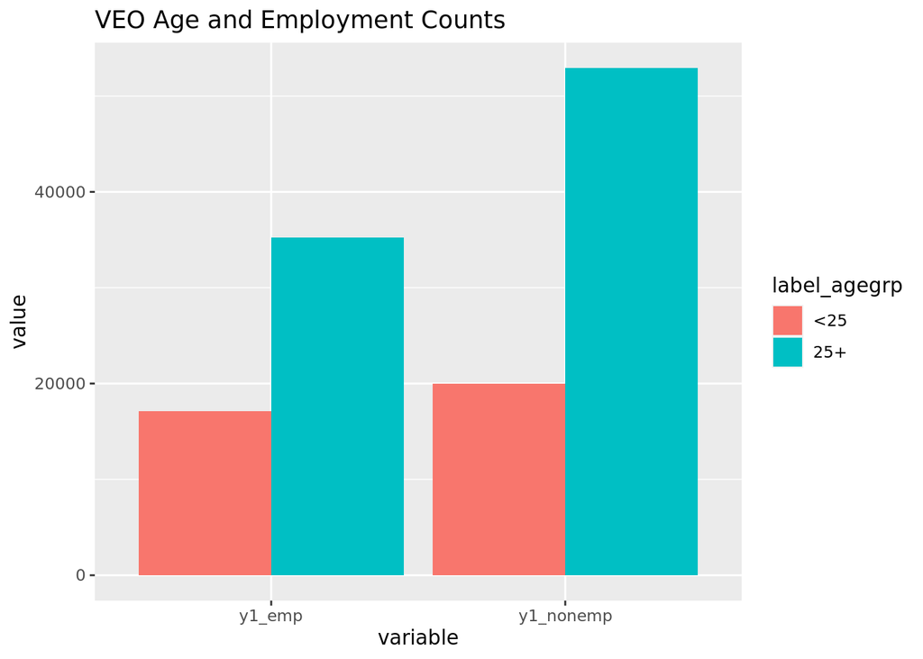

```r
# Age at enlistment
veo_age_long <- veo_age %>% select(label_cohort, label_agegrp, y1_emp, y1_nonemp) %>% melt(id.vars = c("label_cohort", "label_agegrp"))

veo_age_long$value <- as.numeric(veo_age_long$value)

ggplot(veo_age_long, aes(x = variable, y = value, fill = label_agegrp)) +
  geom_col(position = "dodge") +
  labs(title = "VEO Age and Employment Counts")
```

# Sex and Employment Counts

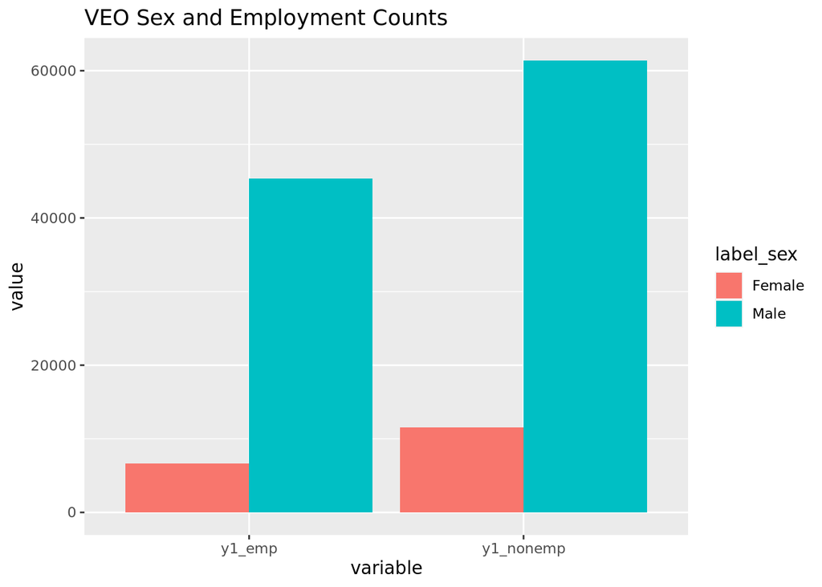

```r
veo_sex_long <- veo_sex %>% select(label_cohort, label_sex, y1_emp, y1_nonemp) %>% melt(id.vars = c("label_cohort", "label_sex"))

veo_sex_long$value <- as.numeric(veo_sex_long$value)

ggplot(veo_sex_long, aes(x = variable, y = value, fill = label_sex)) +
  geom_col(position = "dodge") +
  labs(title = "VEO Sex and Employment Counts")
```

# Education and Employment Counts

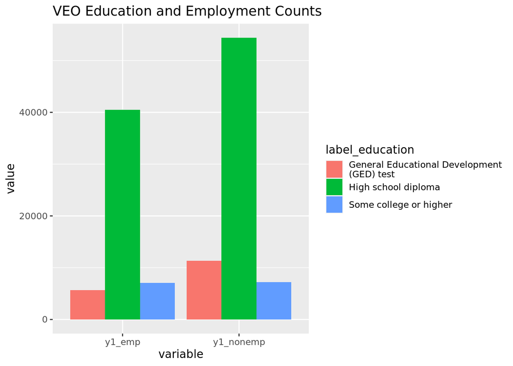

```r
#Education at enlistment
veo_edu_long <- veo_edu %>% select(label_cohort, label_education, y1_emp, y1_nonemp) %>% melt(id.vars = c("label_cohort", "label_education"))

veo_edu_long$value <- as.numeric(veo_edu_long$value)

ggplot(veo_edu_long, aes(x = variable, y = value, fill = label_education)) +
  geom_col(position = "dodge") +
  labs(title = "VEO Education and Employment Counts")
```

# Race and Employment Counts

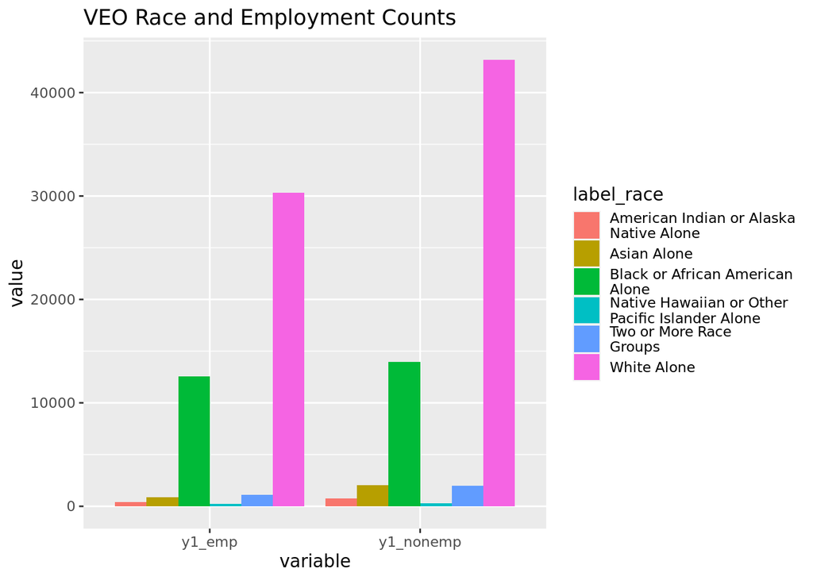

```r
veo_race_long <- veo_race %>% select(label_cohort, label_race, label_ethnicity, y1_emp, y1_nonemp) %>% melt(id.vars = c("label_cohort", "label_race", "label_ethnicity"))

veo_race_long$value <- as.numeric(veo_race_long$value)

ggplot(veo_race_long, aes(x = variable, y = value, fill = label_race)) +
  geom_col(position = "dodge") +
  labs(title = "VEO Race and Employment Counts")
```

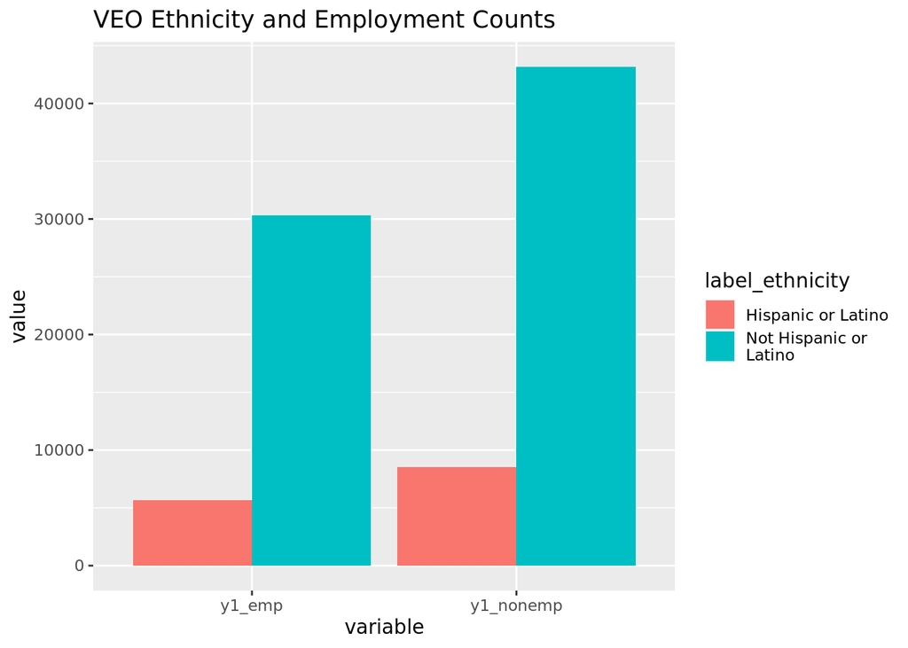

```r
ggplot(veo_race_long, aes(x = variable, y = value, fill = label_ethnicity)) +
  geom_col(position = "dodge") +
  labs(title = "VEO Ethnicity and Employment Counts")
```

# VEO Occupation and Employment Counts

```r
# Read in crosswalk between DOD and SOC codes
crosswalk <- read_csv("~/git/DSPG2020/career/src/lehd/milx0120.csv")
military <- read_csv("~/git/DSPG2020/career/src/lehd/Military_Specific.csv")
```

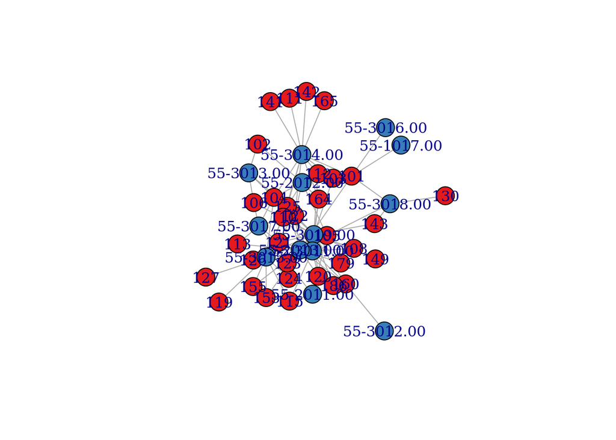

```r
mil_crosswalk <- crosswalk %>% select(DODOCC, ONET1) %>% filter(ONET1 %in% military$Code) %>% transmute(DODOCC = str_extract(DODOCC, "[0-9][0-9][0-9]"), ONET1) %>% distinct() %>% filter(DODOCC <= 186)

mil_crosswalk_nodes <- gather(mil_crosswalk) %>% select(value, key) %>% distinct()

net <- graph_from_data_frame(d=mil_crosswalk, vertices = mil_crosswalk_nodes, directed = F)

library(RColorBrewer)
coul  <- brewer.pal(2, "Set1")
my_color <- coul[as.numeric(as.factor(V(net)$key))]

plot(net, vertex.color=my_color)
```

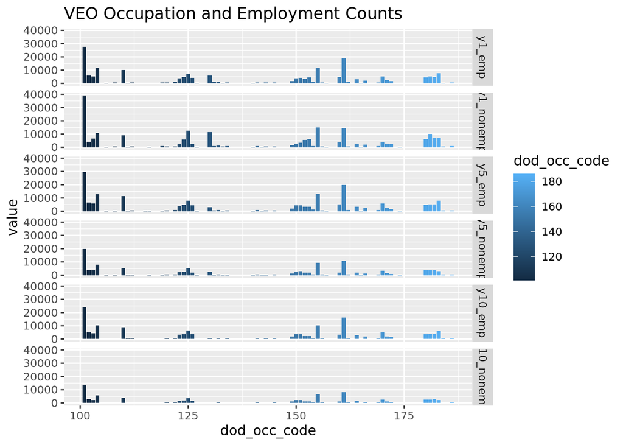

```r
veo_occ_long <- veo_occ %>% select(label_cohort, dod_occ_code, y1_emp, y1_nonemp, y5_emp, y5_nonemp, y10_emp, y10_nonemp) %>% melt(id.vars = c("label_cohort", "dod_occ_code"))

veo_occ_long$value <- as.numeric(veo_occ_long$value)

ggplot(veo_occ_long, aes(x = dod_occ_code, y = value, fill = dod_occ_code)) +
  geom_col(position = "dodge") +
  facet_grid(rows = vars(variable)) +
  labs(title = "VEO Occupation and Employment Counts")
```

# VEO Industry and Employment Counts

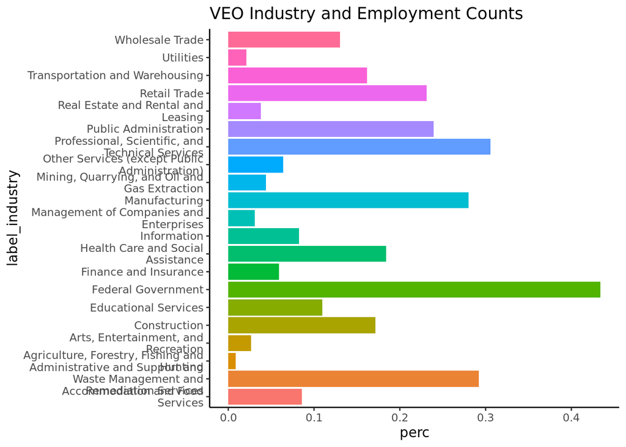

```r
veo_ind_long <- veo_ind %>% select(label_cohort, label_industry, industry, y1_emp, y5_emp, y10_emp) %>% melt(id.vars = c("label_cohort", "label_industry", "industry"))

veo_ind_long$value <- as.integer(veo_ind_long$value)

veo_ind_long_perc <- veo_ind_long %>% drop_na() %>% group_by(variable) %>% mutate(perc = value/sum(value))

ggplot(veo_ind_long_perc, aes(filter(variable = y1_emp), x = label_industry, y = perc, fill = label_industry)) +
  geom_col(show.legend = FALSE) +
  labs(title = "VEO Industry and Employment Counts") +
  #facet_grid(rows = vars(variable)) +
  coord_flip() +
  theme_classic()
```

```r
military <- "55-[0-9][0-9][0-9][0-9].[0-9][0-9]"

military_ids <- job %>% filter(str_detect(job$onet, military)) %>% distinct(id)

res_mil <- job %>% filter(id %in% military_ids$id) %>% group_by(sector) %>% summarise(n = n()) %>% drop_na()
```

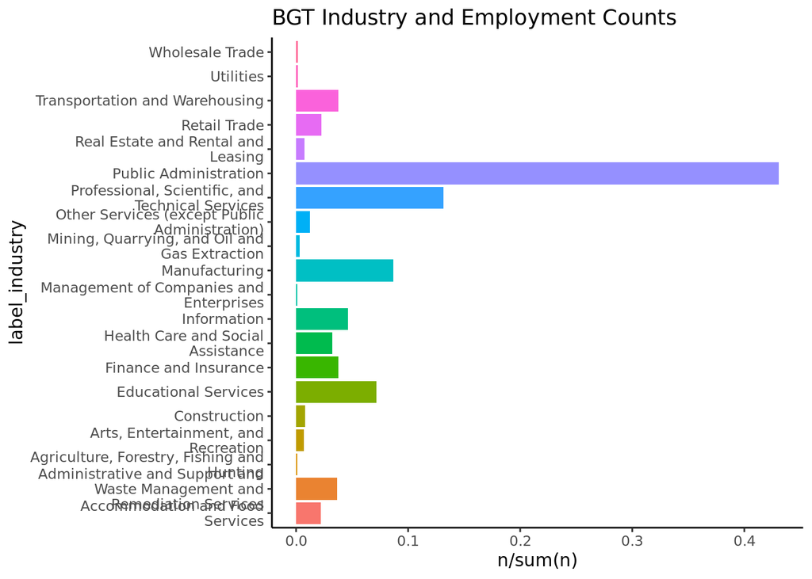

```r
res_mil_labels <- res_mil %>% left_join(select(veo_ind_long, label_industry, industry), by = c("sector" = "industry"))

ggplot(res_mil_labels, aes(x = label_industry, y = n/sum(n), fill = label_industry)) +
  geom_col(show.legend = FALSE) +
  labs(title = "BGT Industry and Employment Counts") +
  coord_flip() +
  theme_classic()
```